# Clustering

Manel Roumaissa Benabid

2022-05-02

```r
setwd("C:/Users/Owner/Desktop/LAU/Fall2022/CSC498H Data Mining")

library(tidyverse)  # data manipulation
library(cluster)    # clustering algorithms
library(factoextra) # visualizing clusters
```

We are going to use the life expectancy data from the regression phase, but we take teh target variable as a normal feature instead of trying to predict it.

loading our data

```r
df1 <- read.csv("life_expectancy.csv", header=TRUE)
df1 <- subset(df1, select = -c(1,2,3) )
```

we need to scale our data for clustering

```r
df <- scale(df1)
```

we compute the distance between the observations and plot it using a heatmap

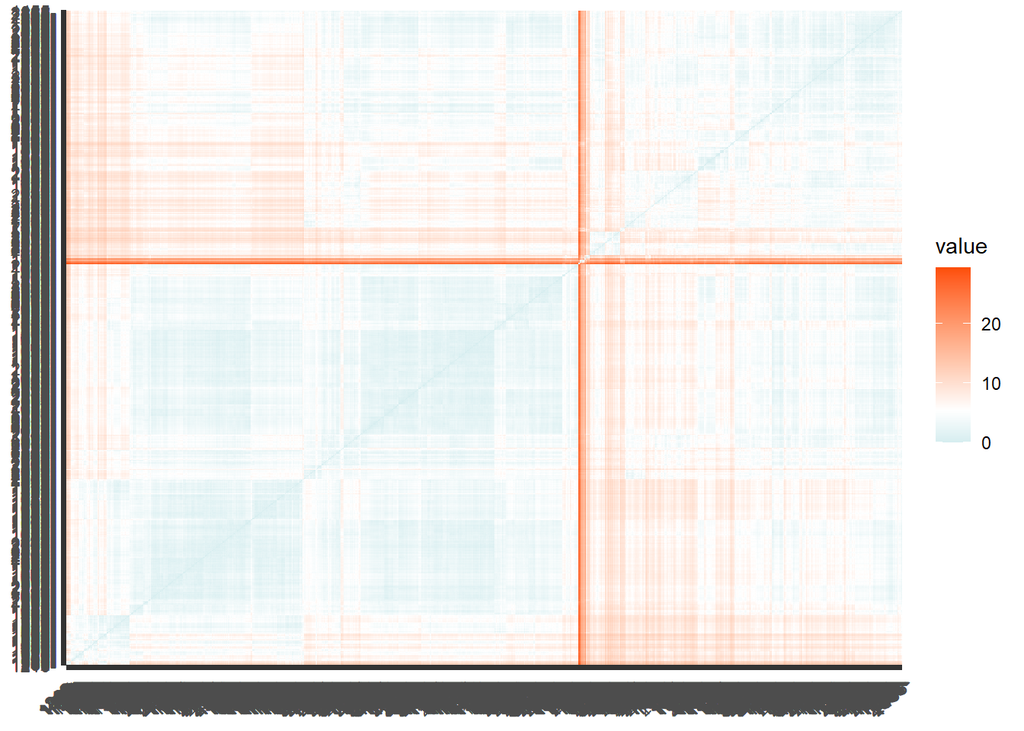

```r
distance <- get_dist(df)
fviz_dist(distance, gradient = list(low = "#00AFBB", mid = "white", high = "#FC4E07"))
```

applying kmeans on our data with 2 centroids (k =2)

```r
k2 <- kmeans(df, centers = 2, nstart = 25)
str(k2)
```

```
## List of 9
##  $ cluster     : Named int [1:2238] 2 2 2 2 2 2 2 2 2 2 ...
##   ..- attr(*, "names")= chr [1:2238] "1" "2" "3" "4" ...
##  $ centers     : num [1:2, 1:19] 0.647 -0.91 -0.435 0.612 -0.213 ...
##   ..- attr(*, "dimnames")=List of 2
##   .. ..$ : chr [1:2] "1" "2"
##   .. ..$ : chr [1:19] "Life.expectancy" "Adult.Mortality" "infant.deaths" "Alcohol" ...
##  $ totss       : num 42503
##  $ withinss    : num [1:2] 11631 20425
##  $ tot.withinss: num 32056
##  $ betweenss   : num 10447
##  $ size        : int [1:2] 1308 930
##  $ iter        : int 1
##  $ ifault      : int 0
##  - attr(*, "class")= chr "kmeans"
```

```r
k2
```

```
## K-means clustering with 2 clusters of sizes 1308, 930
##
## Cluster means:
##   Life.expectancy Adult.Mortality infant.deaths    Alcohol
## 1       0.6471271      -0.4348185    -0.2127138  0.4050752
## 2      -0.9101530       0.6115512     0.2991716 -0.5697186
##   percentage.expenditure Hepatitis.B    Measles        BMI under.five.deaths
## 1              0.2548403   0.3322874 -0.1584806  0.5618393        -0.2240341
## 2             -0.3584206  -0.4673461  0.2228953 -0.7901997         0.3150931
##        Polio Total.expenditure Diphtheria   HIV.AIDS        GDP  Population
## 1  0.4837581         0.2357973  0.4083530 -0.3243603  0.2909594 -0.07214723
## 2 -0.6803823        -0.3316376 -0.5743287  0.4561971 -0.4092203  0.10147159
##   thinness..1.19.years thinness.5.9.years Income.composition.of.resources
## 1             -0.50530         -0.5127890                       0.6288005
## 2              0.71068          0.7212129                      -0.8843775
```

[output cut: 294 more lines]

we have two clusters of size 930, 1308

Let’s visualize them using factoextra library

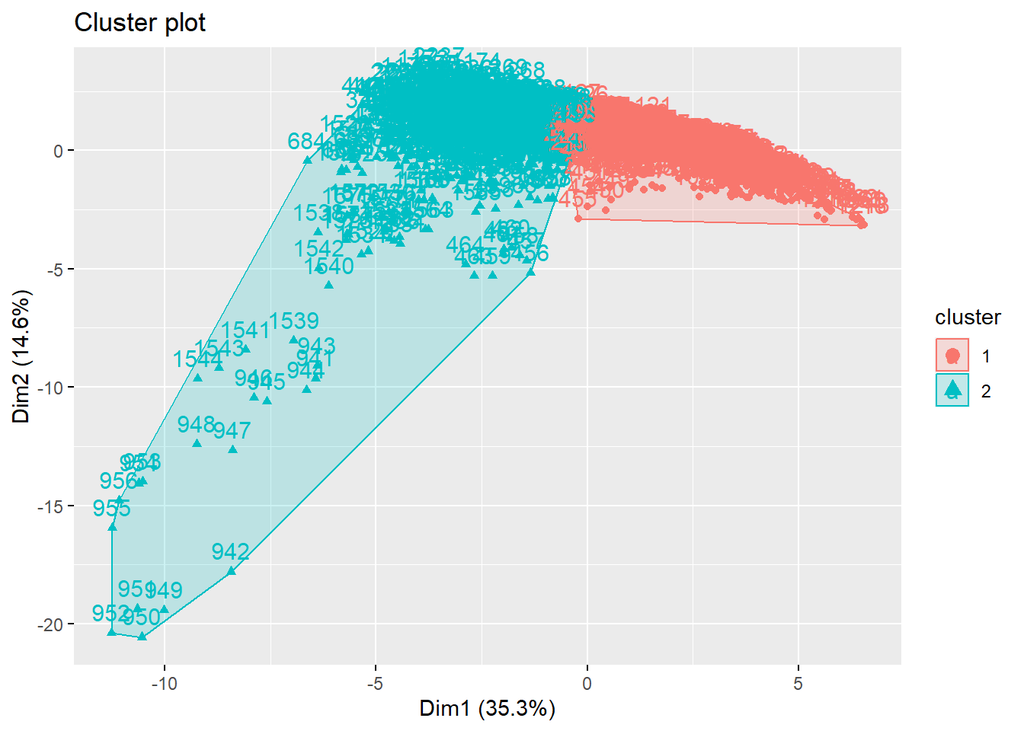

```r
fviz_cluster(k2, data = df)
```

now let’s create more and plot them

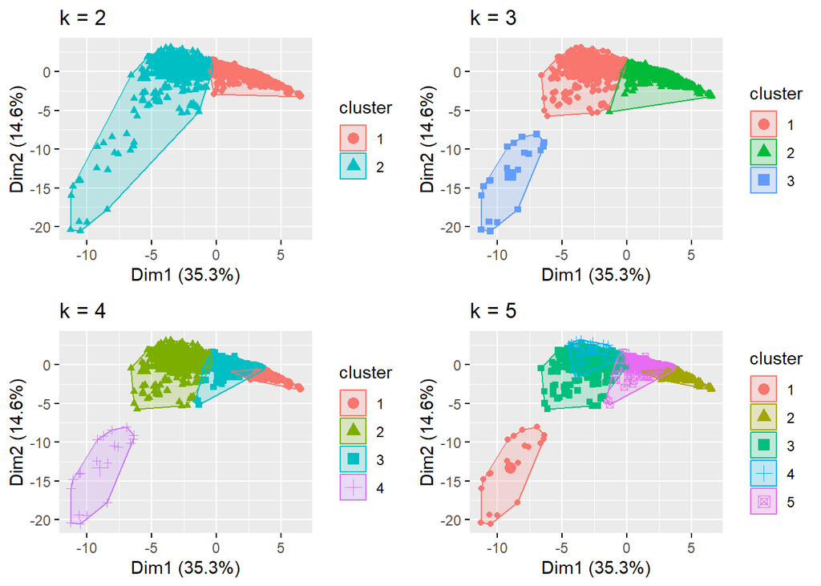

```r
k3 <- kmeans(df, centers = 3, nstart = 25)
k4 <- kmeans(df, centers = 4, nstart = 25)
k5 <- kmeans(df, centers = 5, nstart = 25)

# plots to compare
p1 <- fviz_cluster(k2, geom = "point", data = df) + ggtitle("k = 2")
p2 <- fviz_cluster(k3, geom = "point",  data = df) + ggtitle("k = 3")
p3 <- fviz_cluster(k4, geom = "point",  data = df) + ggtitle("k = 4")
p4 <- fviz_cluster(k5, geom = "point",  data = df) + ggtitle("k = 5")

library(gridExtra)
grid.arrange(p1, p2, p3, p4, nrow = 2)
```

we notice that our observations are very close to each other with some clusters of data far a bit

# Determining Optimal Clusters

## Elbow Method

We check where is the steepest decline in the graph

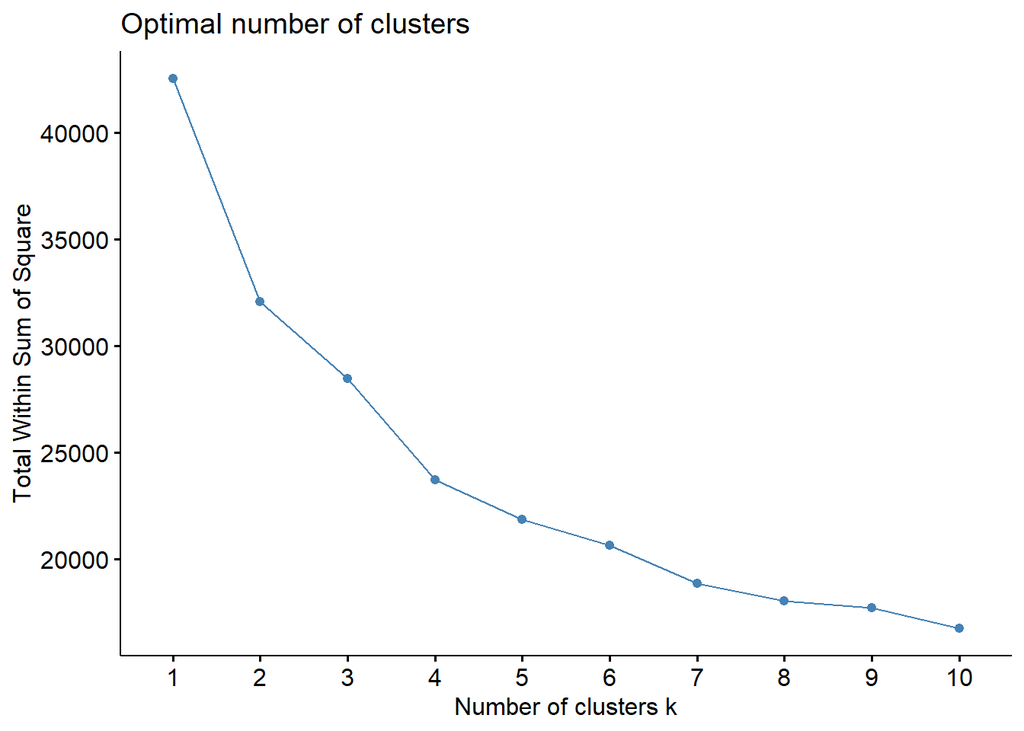

```r
set.seed(123)

fviz_nbclust(df, kmeans, method = "wss")
```

this one says it’s at 2 clusters

## Average Silhouette Method

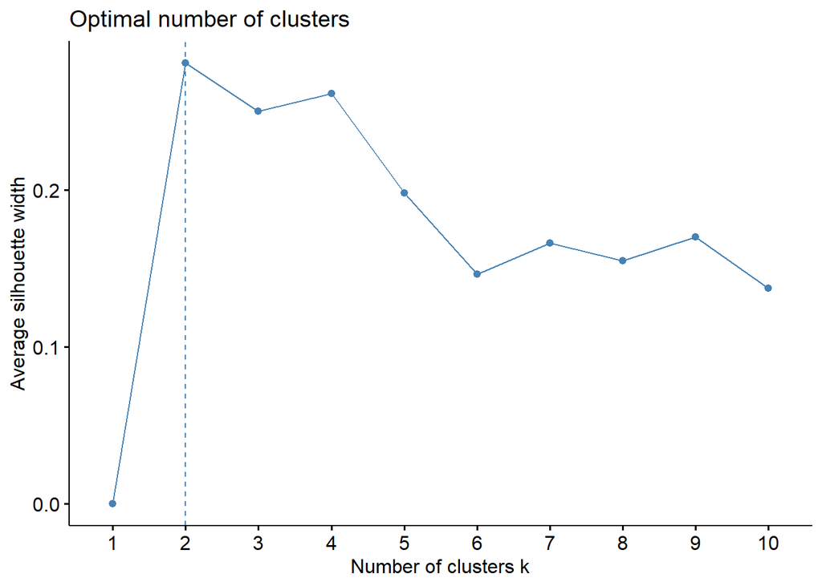

```r
fviz_nbclust(df, kmeans, method = "silhouette")
```

This method also suggests 2 clusters as the best to explain the variability in the data

## Gap statistic Method

```r
set.seed(123)
gap_stat <- clusGap(df, FUN = kmeans, nstart = 25,
                    K.max = 10, B = 50)
# Print the result
print(gap_stat, method = "firstmax")
```

```
## Clustering Gap statistic ["clusGap"] from call:
## clusGap(x = df, FUNcluster = kmeans, K.max = 10, B = 50, nstart = 25)
## B=50 simulated reference sets, k = 1..10; spaceH0="scaledPCA"
##  --> Number of clusters (method 'firstmax'): 2
##           logW   E.logW      gap      SE.sim
##  [1,] 8.020941 9.287892 1.266951 0.002709385
##  [2,] 7.856349 9.191284 1.334935 0.002937033
##  [3,] 7.818892 9.138065 1.319172 0.002653789
##  [4,] 7.745300 9.098430 1.353130 0.002609903
##  [5,] 7.708373 9.072701 1.364328 0.002565530
##  [6,] 7.658715 9.050138 1.391423 0.002449807
##  [7,] 7.641144 9.033244 1.392100 0.002624386
##  [8,] 7.600311 9.017945 1.417634 0.002641932
##  [9,] 7.573960 9.007996 1.434036 0.002469905
## [10,] 7.559935 8.998952 1.439016 0.002460130
```

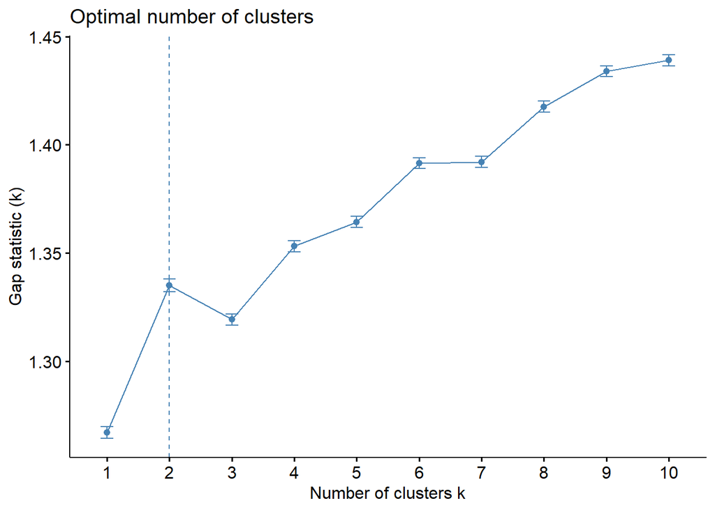

```r
fviz_gap_stat(gap_stat)
```

we note that according to the previous methods, the best number of cluster is 2 by majority vote

# Hierarchical Clustering

```r
library(dendextend) # for comparing two dendrograms
```

function “hclust” and “agnes” for agglomerative hierarchical clustering (HC) “diana” for divisive HC

First we compute the dissimilarity values with “dist” and feed it to “hclust” and specify the agglomeration method to be used (complete, average, single, ward.D)

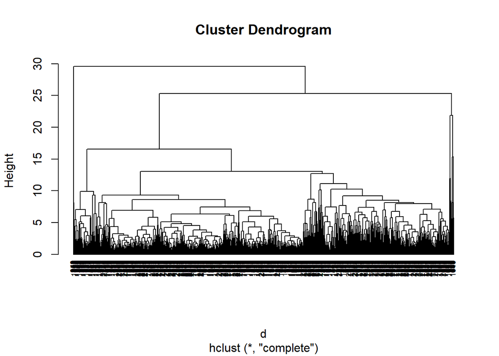

```r
# Dissimilarity matrix
d <- dist(df, method = "euclidean")

# Hierarchical clustering using Complete Linkage
hc1 <- hclust(d, method = "complete" )

# Plot the obtained dendrogram
plot(hc1, cex = 0.6, hang = -1)
```

agnes function you can also get the agglomerative coefficient, which measures the amount of clustering structure found (values closer to 1 suggest strong clustering structure)

```r
# Compute with agnes
hc2 <- agnes(df, method = "complete")

# Agglomerative coefficient
hc2$ac
```

```
## [1] 0.9688931
```

```r
# methods to assess
m <- c( "average", "single", "complete", "ward")
names(m) <- c( "average", "single", "complete", "ward")

# function to compute coefficient
ac <- function(x) {
  agnes(df, method = x)$ac
}

map_dbl(m, ac)
```

```
##   average    single  complete      ward
## 0.9653489 0.9493124 0.9688931 0.9934147
```

We see that Ward’s method identifies the strongest clustering structure

Let’s visualize the dendrogram

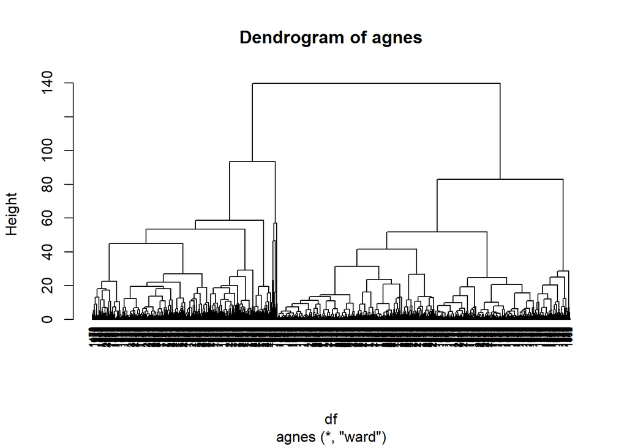

```r
hc3 <- agnes(df, method = "ward")
pltree(hc3, cex = 0.6, hang = -1, main = "Dendrogram of agnes")
```

# Divisive Hierarchical clustering

“diana” works similar to agnes but we do not give it any method

```r
# compute divisive hierarchical clustering
hc4 <- diana(df)

# Divise coefficient; amount of clustering structure found
hc4$dc
```

```
## [1] 0.9643597
```

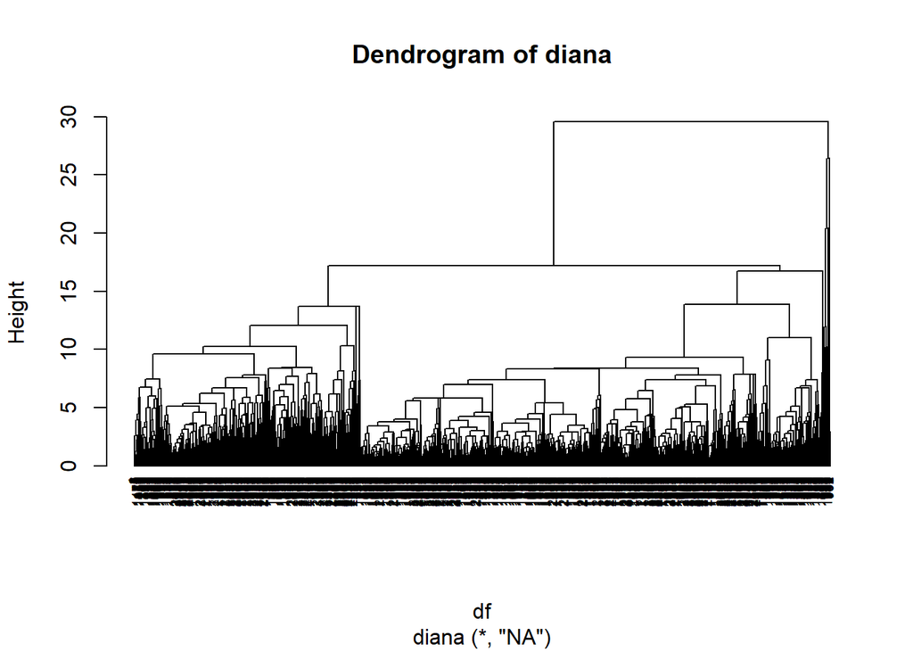

```r
## [1] 0.8514345

# plot dendrogram
pltree(hc4, cex = 0.6, hang = -1, main = "Dendrogram of diana")
```

In the dendrograms we obtained earlier, each leaf corresponds to one observation. As we go up, similar observations are grouped together into branches.

The height of the fusion, provided on the vertical axis, indicates the (dis)similarity between two observations. The higher the height of the fusion, the less similar the observations are.

In order to identify sub-groups (i.e. clusters), we can cut the dendrogram with “cutree”:

```r
# Ward's method
hc5 <- hclust(d, method = "ward.D2" )

# Cut tree into 4 groups
sub_grp <- cutree(hc5, k = 4)

# Number of members in each cluster
table(sub_grp)
```

```
## sub_grp
##    1    2    3    4
##  837 1202  169   30
```

Drawing a 4 cluster dendrogram

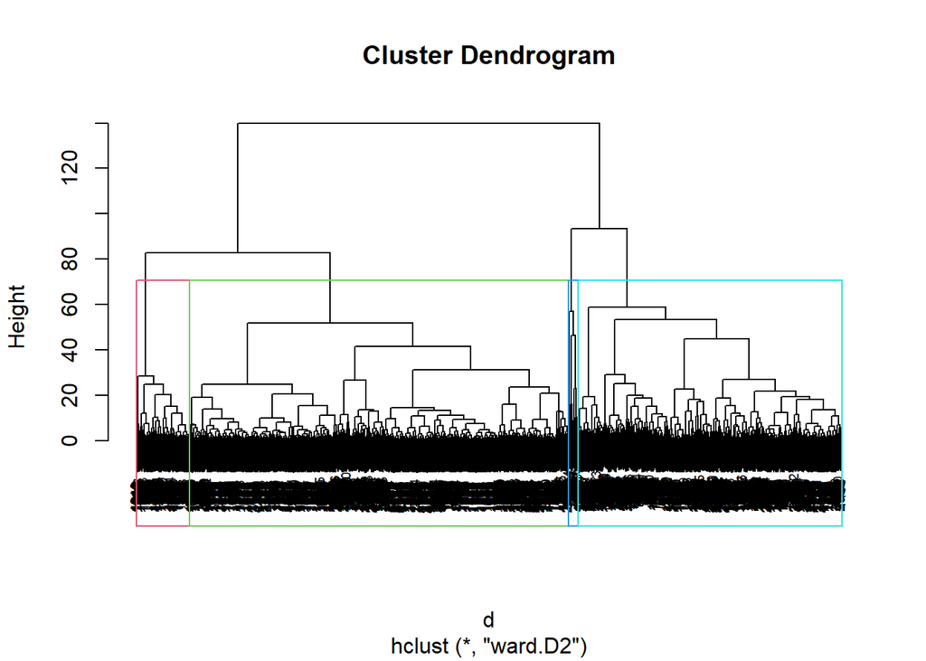

```r
plot(hc5, cex = 0.6)
rect.hclust(hc5, k = 4, border = 2:5)
```

We can use the “fviz_cluster” from factoextra package to visualize the result in a scatter plot.

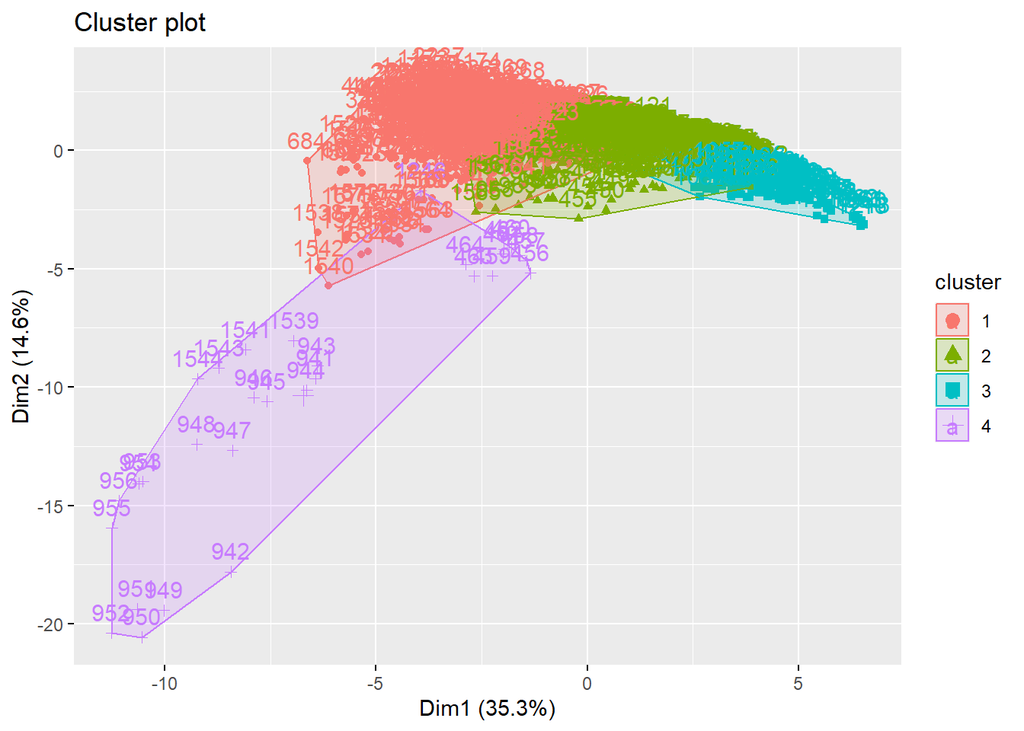

```r
fviz_cluster(list(data = df, cluster = sub_grp))
```

We can use “cutree” with “agnes” and “diana”

```r
# Cut agnes() tree into 4 groups
hc_a <- agnes(df, method = "ward")
cutree(as.hclust(hc_a), k = 4)
```

```
##    1    2    3    4    5    6    7    8    9   10   11   12   13   14   15   16
##    1    1    1    1    1    1    1    1    1    1    1    1    1    1    1    1
##   17   18   19   20   21   22   23   24   25   26   27   28   29   30   31   32
##    2    2    2    2    2    2    2    2    2    2    2    2    2    2    2    2
##   33   34   35   36   37   38   39   40   41   42   43   44   45   46   47   48
##    2    2    2    2    2    2    2    2    2    2    2    2    2    2    2    2
##   49   50   51   52   53   54   55   56   57   58   59   60   61   62   63   64
##    1    1    1    1    1    1    1    1    1    1    1    1    1    1    1    1
##   65   66   67   68   69   70   71   72   73   74   75   76   77   78   79   80
##    2    2    2    2    2    2    2    2    2    2    2    2    2    2    2    2
##   81   82   83   84   85   86   87   88   89   90   91   92   93   94   95   96
##    2    2    2    2    2    2    2    2    2    2    2    2    2    2    2    2
##   97   98   99  100  101  102  103  104  105  106  107  108  109  110  111  112
##    3    3    3    3    3    3    3    3    2    3    2    2    3    2    2    2
##  113  114  115  116  117  118  119  120  121  122  123  124  125  126  127  128
```

[output cut: 265 more lines]

```r
# Cut diana() tree into 4 groups
hc_d <- diana(df)
cutree(as.hclust(hc_d), k = 4)
```

```
##    1    2    3    4    5    6    7    8    9   10   11   12   13   14   15   16
##    1    1    1    1    1    1    1    1    1    1    1    1    1    1    1    1
##   17   18   19   20   21   22   23   24   25   26   27   28   29   30   31   32
##    1    1    1    1    1    1    1    1    1    1    1    1    1    1    1    1
##   33   34   35   36   37   38   39   40   41   42   43   44   45   46   47   48
##    1    1    1    1    1    1    1    1    1    1    1    1    1    1    1    1
##   49   50   51   52   53   54   55   56   57   58   59   60   61   62   63   64
##    1    1    1    1    1    1    1    1    1    1    1    1    1    1    1    1
##   65   66   67   68   69   70   71   72   73   74   75   76   77   78   79   80
##    1    1    1    1    1    1    1    1    1    1    1    1    1    1    1    1
##   81   82   83   84   85   86   87   88   89   90   91   92   93   94   95   96
##    1    1    1    1    1    1    1    1    1    1    1    1    1    1    1    1
##   97   98   99  100  101  102  103  104  105  106  107  108  109  110  111  112
##    1    1    1    1    1    1    1    1    1    1    1    1    1    1    1    1
##  113  114  115  116  117  118  119  120  121  122  123  124  125  126  127  128
```

[output cut: 265 more lines]

And for the final act, I’m going to be killing myself.

Just kidding, we are going to compare two dendrograms. We will compare hierarchical clustering with complete linkage vc. Ward’s method.

To plot the two dendrograms side by side with their labels connected by lines, we use “tanglegram”

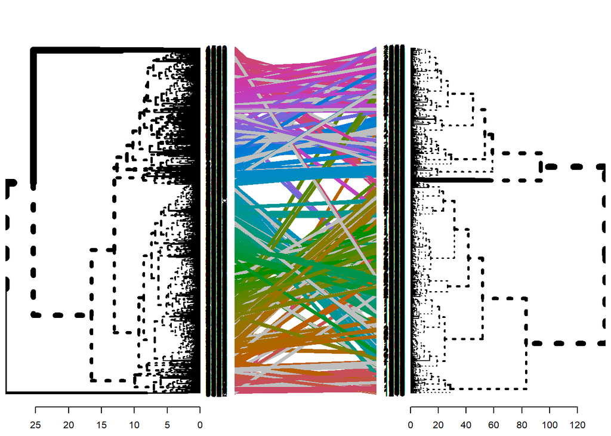

```r
# Compute distance matrix
res.dist <- dist(df, method = "euclidean")

# Compute 2 hierarchical clusterings
hc1 <- hclust(res.dist, method = "complete")
hc2 <- hclust(res.dist, method = "ward.D2")

# Create two dendrograms
dend1 <- as.dendrogram (hc1)
dend2 <- as.dendrogram (hc2)

tanglegram(dend1, dend2)
```

Ugly and Beautiful at the same time

# Principle Component Analysis

Step1: calculate the covariance matrix of the features

```r
lalaland.cov <- cov(df)
```

Step2: calculate the eigenvalues and eigenvectors

```r
lalaland.eigen <- eigen(lalaland.cov)
str(lalaland.eigen)
```

```
## List of 2
##  $ values : num [1:19] 6.71 2.77 1.79 1.42 1.12 ...
##  $ vectors: num [1:19, 1:19] 0.325 -0.211 -0.184 0.233 0.208 ...
##  - attr(*, "class")= chr "eigen"
```

Let’s take the first two and store them in a matrix, let’s call it phi

```r
# Extract the loadings
(phi <- lalaland.eigen$vectors[,1:2])
```

```
##              [,1]         [,2]
##  [1,]  0.32457197 -0.182776362
##  [2,] -0.21140033  0.194847736
##  [3,] -0.18425616 -0.486413774
##  [4,]  0.23294395 -0.126206080
##  [5,]  0.20849548 -0.174461894
##  [6,]  0.16294876  0.057004466
##  [7,] -0.12232845 -0.323991981
##  [8,]  0.26992749 -0.039683155
##  [9,] -0.19052400 -0.479740371
## [10,]  0.25366127 -0.019498451
## [11,]  0.14803114  0.007673242
## [12,]  0.21084550 -0.049722646
## [13,] -0.14172238  0.155710948
## [14,]  0.22407364 -0.179555975
## [15,] -0.08432159 -0.382815523
## [16,] -0.28400400 -0.157408666
## [17,] -0.28263805 -0.160053993
## [18,]  0.30795075 -0.169307584
## [19,]  0.32265914 -0.143919343
```

We will take the eigenvectors pointing in the positive direction simply because it makes sense interpretabily and graphically.

```r
phi <- -phi
row.names(phi) <- colnames(df1)
colnames(phi) <- c("PC1", "PC2")
phi
```

```
##                                         PC1          PC2
## Life.expectancy                 -0.32457197  0.182776362
## Adult.Mortality                  0.21140033 -0.194847736
## infant.deaths                    0.18425616  0.486413774
## Alcohol                         -0.23294395  0.126206080
## percentage.expenditure          -0.20849548  0.174461894
## Hepatitis.B                     -0.16294876 -0.057004466
## Measles                          0.12232845  0.323991981
## BMI                             -0.26992749  0.039683155
## under.five.deaths                0.19052400  0.479740371
## Polio                           -0.25366127  0.019498451
## Total.expenditure               -0.14803114 -0.007673242
## Diphtheria                      -0.21084550  0.049722646
## HIV.AIDS                         0.14172238 -0.155710948
## GDP                             -0.22407364  0.179555975
## Population                       0.08432159  0.382815523
## thinness..1.19.years             0.28400400  0.157408666
## thinness.5.9.years               0.28263805  0.160053993
## Income.composition.of.resources -0.30795075  0.169307584
## Schooling                       -0.32265914  0.143919343
```

each PC defines a direction in feature space. Because eigenvectors are orthogonal to every other eigenvector. i.e. they are not correlated with each other.

```r
# Calculate Principal Components scores
PC1 <- as.matrix(df) %*% phi[,1]
PC2 <- as.matrix(df) %*% phi[,2]
```

```r
row.names(df1) <- 1:dim(df1)[1]
```

```r
PC <- data.frame(id = row.names(df1), PC1, PC2)
head(PC)
```

```
##   id      PC1       PC2
## 1  1 3.071151 0.4485676
## 2  2 3.846460 0.1032876
## 3  3 3.831503 0.3229649
## 4  4 3.729829 0.2307636
## 5  5 3.851217 0.2247302
## 6  6 3.914464 0.2085490
```

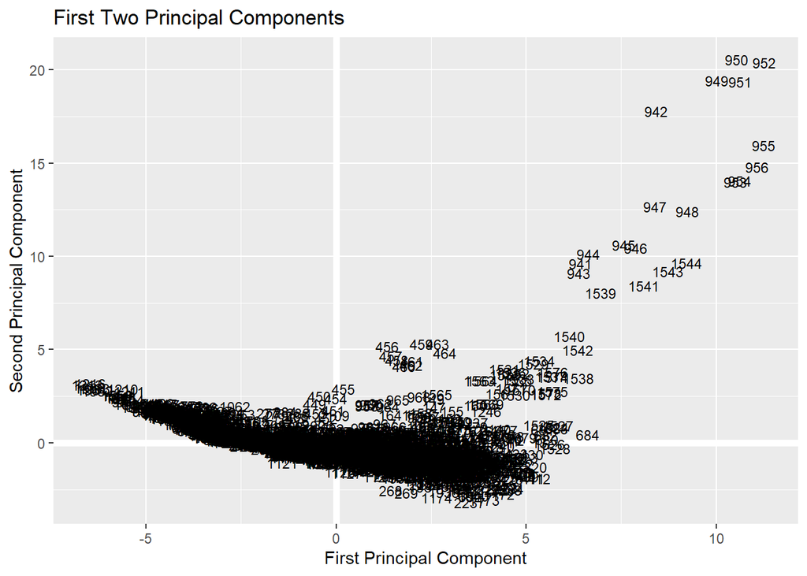

```r
# Plot Principal Components for each State
ggplot(PC, aes(PC1, PC2)) +
  modelr::geom_ref_line(h = 0) +
  modelr::geom_ref_line(v = 0) +
  geom_text(aes(label = id), size = 3) +
  xlab("First Principal Component") +
  ylab("Second Principal Component") +
  ggtitle("First Two Principal Components")
```

## Selecting number of PCs

we calculate the the proportion of the variance explained (PVE) by the mth PC

```r
PVE <- lalaland.eigen$values / sum(lalaland.eigen$values)
round(PVE, 2)
```

```
##  [1] 0.35 0.15 0.09 0.07 0.06 0.04 0.04 0.04 0.03 0.03 0.02 0.02 0.02 0.02 0.01
## [16] 0.01 0.00 0.00 0.00
```

Let’s plot it, it’s better to visualize data, maybe if we visualize them better, we get the opportunity to audit data viz class

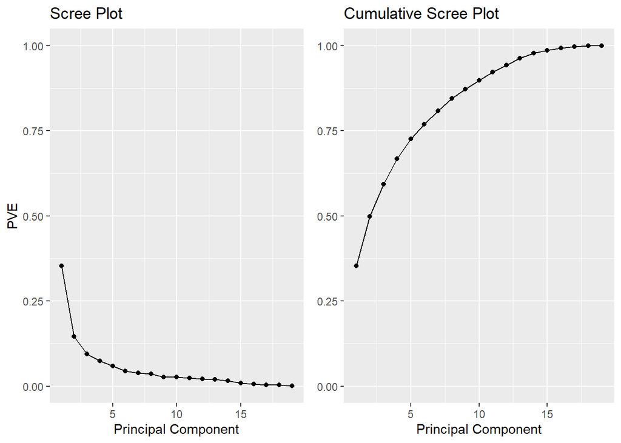

```r
# PVE plot
PVEplot <- qplot(c(1:19), PVE) +
  geom_line() +
  xlab("Principal Component") +
  ylab("PVE") +
  ggtitle("Scree Plot") +
  ylim(0, 1)
# Cumulative PVE plot
cumPVE <- qplot(c(1:19), cumsum(PVE)) +
  geom_line() +
  xlab("Principal Component") +
  ylab(NULL) +
  ggtitle("Cumulative Scree Plot") +
  ylim(0,1)

grid.arrange(PVEplot, cumPVE, ncol = 2)
```

## How many PCs do we use?

We can use the elbow point (using our naked eye) to guess that the best number (we want the minimum) of PCs to choose is 2.

# Conclusion

In this document we performed kmeans, hierarchical and divisive clustering, and Principle Component Analysis on the life expectancy dataset. In this analysis we took the variable “life expectancy” as a feature instead of a target variable.

Can I audit data viz, please?